# Spatial correlation - few minimal examples

Thomas Bury Human Bender DS

2019-07-12

[figure not shown]

# 1 Forewords

## 1.1 Disclaimer

Those minimal examples are done to illustrate the different models. I didn’t follow the standard methodology. Especially, the models are fitted using the whole data set and the outcomes are compared loosely and in a visual way. However, the strengths and weaknesses can be grasped with those simple examples. Moreover some methods to clean the data (filter the noise) might be applied but are not described here. I think of filtering out the noise of the correlation matrix. Pretty common for temporal correlation (especially in finance and physics), those methods might be applied to the spatial correlation matrix. To be investigated.

## 1.2 Maps in R

One of the best tuto: https://github.com/Robinlovelace/Creating-maps-in-R and the magnificent Leaflet https://rstudio.github.io/leaflet/

## 1.3 Spatial modelling

There are different way to model spatial dependencies. Among them, there are:

- Spatial auto-regressive model (where potentially every location has an influence on another one). A SAR model can be written as a CAR (analogies to AR and MA in time series)
- Conditional auto-regressive model (CAR). A more modern denomination: Gaussian Markov Random field
- Gaussian processes (aka kriging is geo-stat), the (space) continuous counterpart of the GMRF. Often easier to deal with
- Spatial error model (the error)
- GAM and their extensions (GAMLSS, etc.)
- Mixed models allow to model spatial correlation using a random effect (loosely allow to use correlated errors and clustering)
- Bayesian hierarchical models (not demonstrated, not an expert and requires to perform sampling “externally” using JAGS, BUGS, …)

# 2 Chicago

I’ll provide some minimal examples. Those examples are based on http://www.econ.uiuc.edu/~lab/workshop/Spatial_in_R.html and extend to spatial modelling using GAM, Gaussian processes (GP) and Gaussian Markov Random Fields (GMRF).

Those examples will be examining violent crimes and foreclosures in the City of Chicago (open data).

## 2.1 Crime data

Basic plot of the polygons part of the shapefile

```r
data_path = "C:/Users/xtbury/Documents/Projects/Italy projects/002_Zoning/Data files/"
file_name = "foreclosures.shp"
chi.poly <- rgdal::readOGR(paste0(data_path, file_name))
class(chi.poly)
```

```
## [1] "SpatialPolygonsDataFrame"
## attr(,"package")
## [1] "sp"
```

```r
str(slot(chi.poly,"data"))
```

```
## 'data.frame':    897 obs. of  16 variables:
##  $ SP_ID     : Factor w/ 897 levels "1","10","100",..: 1 112 223 334 445 556 667 778 887 2 ...
##  $ fips      : Factor w/ 897 levels "17031010100",..: 1 2 3 4 5 6 7 8 9 10 ...
##  $ est_fcs   : int  43 129 55 21 64 56 107 43 7 51 ...
##  $ est_mtgs  : int  904 2122 1151 574 1427 1241 1959 830 208 928 ...
##  $ est_fcs_rt: num  4.76 6.08 4.78 3.66 4.48 4.51 5.46 5.18 3.37 5.5 ...
##  $ res_addr  : int  2530 3947 3204 2306 5485 2994 3701 1694 443 1552 ...
##  $ est_90d_va: num  12.61 12.36 10.46 5.03 8.44 ...
##  $ bls_unemp : num  8.16 8.16 8.16 8.16 8.16 8.16 8.16 8.16 8.16 8.16 ...
##  $ county    : Factor w/ 1 level "Cook County": 1 1 1 1 1 1 1 1 1 1 ...
##  $ fips_num  : num  1.7e+10 1.7e+10 1.7e+10 1.7e+10 1.7e+10 ...
##  $ totpop    : int  5391 10706 6649 5325 10944 7178 10799 5403 1089 3634 ...
##  $ tothu     : int  2557 3981 3281 2464 5843 3136 3875 1768 453 1555 ...
##  $ huage     : int  61 53 56 60 54 58 48 57 61 48 ...
##  $ oomedval  : int  169900 147000 119800 151500 143600 145900 153400 170500 215900 114700 ...
##  $ property  : num  646 914 478 509 641 612 678 332 147 351 ...
##  $ violent   : num  433 421 235 159 240 266 272 146 78 84 ...
```

```r
summary(chi.poly@data$violent)
```

```
##    Min. 1st Qu.  Median    Mean 3rd Qu.    Max.
##     0.0    49.0   103.0   169.3   226.0  1521.0
```

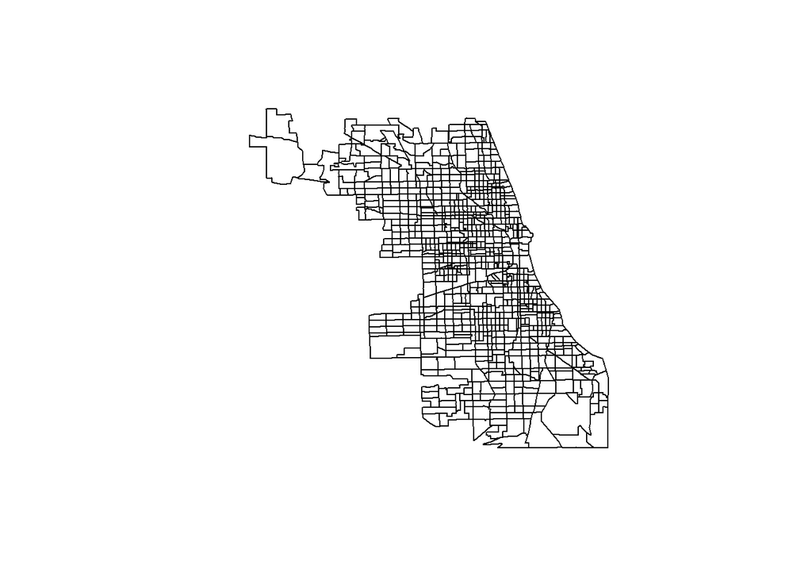

```r
# Default plot, not bad but not that beautiful
plot(chi.poly)
```

Just because leaflet is awesome and it so much better looking than base plot:

```r
leaflet(chi.poly) %>%
  addPolygons(stroke = FALSE, fillOpacity = 0.5, smoothFactor = 0.5) %>%
  addTiles() #adds a map tile, the default is OpenStreetMap
```

[interactive chart not shown]

```r
# qpal <- colorQuantile("inferno", chi.poly@data$violent, n=9)
qpal <- colorQuantile(scico(30, palette = 'roma'), chi.poly@data$violent, n=9)

leaflet(chi.poly) %>%
  addPolygons(stroke = FALSE, fillOpacity = .8, smoothFactor = 0.2, color = ~qpal(violent)
  ) %>%
  addTiles()
```

[interactive chart not shown]

# 3 Spatial statistics

## 3.1 OLS

since OLS does not allow correlated error, heteroskedasticity, etc (Gauss-Markov), It will be a bad benchmark but anyway, let’s consider it as our baseline.

```r
chi.ols<-lm(violent~est_fcs_rt+bls_unemp, data=chi.poly@data)
summary(chi.ols)
```

```
##
## Call:
## lm(formula = violent ~ est_fcs_rt + bls_unemp, data = chi.poly@data)
##
## Residuals:
##     Min      1Q  Median      3Q     Max
## -892.02  -77.02  -23.73   41.90 1238.22
##
## Coefficients:
##             Estimate Std. Error t value Pr(>|t|)
## (Intercept)  -18.627     45.366  -0.411    0.681
## est_fcs_rt    28.298      1.435  19.720   <2e-16 ***
## bls_unemp     -0.308      5.770  -0.053    0.957
## ---
## Signif. codes:  0 '***' 0.001 '**' 0.01 '*' 0.05 '.' 0.1 ' ' 1
##
## Residual standard error: 157.3 on 894 degrees of freedom
## Multiple R-squared:  0.3141, Adjusted R-squared:  0.3126
## F-statistic: 204.7 on 2 and 894 DF,  p-value: < 2.2e-16
```

The problem with ignoring the spatial structure of the data implies that the OLS estimates in the non spatial model may be biased, inconsistent or inefficient

## 3.2 Spatial regression

From the shape file we can extract the neighborhood (the lattice)

```r
# neighbors: all the touching nodes, other choices possible
list.queen <- poly2nb(chi.poly, queen=TRUE)
# convert th neighborhood in a list
W <- nb2listw(list.queen, style="W", zero.policy=TRUE)
W
```

```
## Characteristics of weights list object:
## Neighbour list object:
## Number of regions: 897
## Number of nonzero links: 6140
## Percentage nonzero weights: 0.7631036
## Average number of links: 6.845039
##
## Weights style: W
## Weights constants summary:
##     n     nn  S0       S1       S2
## W 897 804609 897 274.4893 3640.864
```

A basic plot of the neighborhood

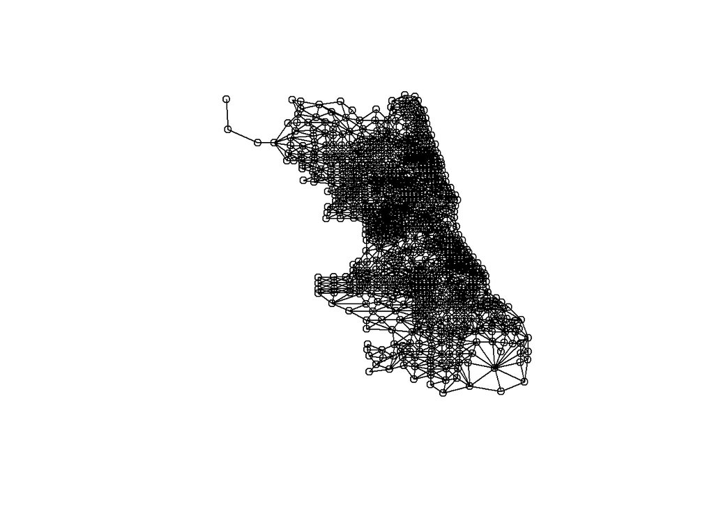

```r
plot(W,coordinates(chi.poly))
```

We can even extract the coordinates for latter convenience

```r
coords <- coordinates(chi.poly)
W_dist <- dnearneigh(coords,0,1,longlat = FALSE)
```

## 3.3 Testing the spatial correlation

Did we miss something by ignoring the spatial structure ?

```r
# Moran test
moran.lm <- lm.morantest(chi.ols, W, alternative="two.sided")
print(moran.lm)
```

```
##
##  Global Moran I for regression residuals
##
## data:
## model: lm(formula = violent ~ est_fcs_rt + bls_unemp, data =
## chi.poly@data)
## weights: W
##
## Moran I statistic standard deviate = 11.785, p-value < 2.2e-16
## alternative hypothesis: two.sided
## sample estimates:
## Observed Moran I      Expectation         Variance
##     0.2142252370    -0.0020099108     0.0003366648
```

```r
# Lagrange multiplier test
LM <- lm.LMtests(chi.ols, W, test="all")
print(LM)
```

```
##
##  Lagrange multiplier diagnostics for spatial dependence
##
## data:
## model: lm(formula = violent ~ est_fcs_rt + bls_unemp, data =
## chi.poly@data)
## weights: W
##
## LMerr = 134.52, df = 1, p-value < 2.2e-16
##
##
##  Lagrange multiplier diagnostics for spatial dependence
##
## data:
## model: lm(formula = violent ~ est_fcs_rt + bls_unemp, data =
## chi.poly@data)
## weights: W
##
## LMlag = 182.18, df = 1, p-value < 2.2e-16
##
##
##  Lagrange multiplier diagnostics for spatial dependence
##
## data:
## model: lm(formula = violent ~ est_fcs_rt + bls_unemp, data =
## chi.poly@data)
## weights: W
##
## RLMerr = 0.00066762, df = 1, p-value = 0.9794
##
##
##  Lagrange multiplier diagnostics for spatial dependence
##
## data:
## model: lm(formula = violent ~ est_fcs_rt + bls_unemp, data =
## chi.poly@data)
## weights: W
##
## RLMlag = 47.653, df = 1, p-value = 5.089e-12
##
##
##  Lagrange multiplier diagnostics for spatial dependence
##
## data:
## model: lm(formula = violent ~ est_fcs_rt + bls_unemp, data =
## chi.poly@data)
## weights: W
##
## SARMA = 182.18, df = 2, p-value < 2.2e-16
```

The classical counterpart of time series econometric models are the spatial auto-regressive models and the conditional auto regressive models (SAR and CAR). But they are also Gaussian processes and the discrete counterpart, the Markov Random fields. The Ising model in physics and generally all physical systems described by a Gibbs measure are MRF. In machine learning, GP and MRF found many applications (part of graphical model theory). GP regression is also called kriging in geography and geo-statistics. A blended approach is to use GP as basis in GAM instead of splines.

## 3.4 Spatial autoregression

```r
chi.sar <- lagsarlm(violent~est_fcs_rt+bls_unemp, data=chi.poly@data, W)
summary(chi.sar)
```

```
##
## Call:
## lagsarlm(formula = violent ~ est_fcs_rt + bls_unemp, data = chi.poly@data,
##     listw = W)
##
## Residuals:
##      Min       1Q   Median       3Q      Max
## -519.127  -65.003  -15.226   36.423 1184.193
##
## Type: lag
## Coefficients: (asymptotic standard errors)
##             Estimate Std. Error z value Pr(>|z|)
## (Intercept) -93.7885    41.3162  -2.270  0.02321
## est_fcs_rt   15.6822     1.5600  10.053  < 2e-16
## bls_unemp     8.8949     5.2447   1.696  0.08989
##
## Rho: 0.49037, LR test value: 141.33, p-value: < 2.22e-16
## Asymptotic standard error: 0.039524
##     z-value: 12.407, p-value: < 2.22e-16
## Wald statistic: 153.93, p-value: < 2.22e-16
##
## Log likelihood: -5738.047 for lag model
## ML residual variance (sigma squared): 20200, (sigma: 142.13)
## Number of observations: 897
## Number of parameters estimated: 5
## AIC: 11486, (AIC for lm: 11625)
## LM test for residual autocorrelation
## test value: 8.1464, p-value: 0.0043146
```

## 3.5 Spatial error model

```r
chi.sem <- errorsarlm(violent~est_fcs_rt+bls_unemp, data=chi.poly@data, W)
summary(chi.sem)
```

```
##
## Call:
## errorsarlm(formula = violent ~ est_fcs_rt + bls_unemp, data = chi.poly@data,
##     listw = W)
##
## Residuals:
##      Min       1Q   Median       3Q      Max
## -650.506  -64.355  -22.646   35.461 1206.346
##
## Type: error
## Coefficients: (asymptotic standard errors)
##             Estimate Std. Error z value Pr(>|z|)
## (Intercept)  -1.2624    43.0509 -0.0293   0.9766
## est_fcs_rt   19.4620     1.9450 10.0062   <2e-16
## bls_unemp     4.0380     5.5134  0.7324   0.4639
##
## Lambda: 0.52056, LR test value: 109.68, p-value: < 2.22e-16
## Asymptotic standard error: 0.042291
##     z-value: 12.309, p-value: < 2.22e-16
## Wald statistic: 151.51, p-value: < 2.22e-16
##
## Log likelihood: -5753.875 for error model
## ML residual variance (sigma squared): 20796, (sigma: 144.21)
## Number of observations: 897
## Number of parameters estimated: 5
## AIC: 11518, (AIC for lm: 11625)
```

## 3.6 Conditional autoregression

```r
chi.car <- spautolm(violent~est_fcs_rt+bls_unemp, data=chi.poly@data, listw = W, family = "CAR")
summary(chi.car)
```

```
##
## Call:
## spautolm(formula = violent ~ est_fcs_rt + bls_unemp, data = chi.poly@data,
##     listw = W, family = "CAR")
##
## Residuals:
##      Min       1Q   Median       3Q      Max
## -537.682  -56.778  -11.273   41.108 1153.082
##
## Coefficients:
##              Estimate Std. Error z value  Pr(>|z|)
## (Intercept) -101.3504    45.2299 -2.2408   0.02504
## est_fcs_rt    12.6936     2.1769  5.8311 5.505e-09
## bls_unemp     10.4496     5.4712  1.9099   0.05614
##
## Lambda: 0.93866 LR test value: 138.08 p-value: < 2.22e-16
## Numerical Hessian standard error of lambda: NaN
##
## Log likelihood: -5739.675
## ML residual variance (sigma squared): 18777, (sigma: 137.03)
## Number of observations: 897
## Number of parameters estimated: 5
## AIC: 11489
```

## 3.7 Compare the OLS and SAR

```r
range01 <- function(x, na.rm = T){2*(x - min(x, na.rm = na.rm)) / (max(x, na.rm=na.rm) - min(x, na.rm=na.rm))-1}
n_cols <- 9
spectral_col <- colorRampPalette(brewer.pal(9,"Spectral"))(n_cols)

chi.poly@data$chi.ols.res<-resid(chi.ols) #residuals ols
chi.poly@data$chi.ols.fval <- chi.ols$fitted.values
# spplot(chi.poly,"chi.ols.res", at=seq(min(chi.poly@data$chi.ols.res,na.rm=TRUE),
#                                       max(chi.poly@data$chi.ols.res,na.rm=TRUE),
#                                       length=n_cols),col.regions=spectral_col)

chi.poly@data$chi.sar.res <- resid(chi.sar) #residual sar
chi.poly@data$chi.sar.fval <- chi.sar$fitted.values
# spplot(chi.poly,"chi.sar.res", at=seq(min(chi.poly@data$chi.sar.res,na.rm=TRUE),
#                                       max(chi.poly@data$chi.sar.res,na.rm=TRUE),
#                                       length=n_cols),col.regions=spectral_col)

chi.poly@data$chi.car.res<- chi.car$fit$residuals #residual sar
chi.poly@data$chi.car.fval <- chi.car$fit$fitted.values

chi.poly@data$chi.sem.res<-resid(chi.sem) #residual sar
chi.poly@data$chi.sem.fval <- chi.sem$fitted.values
```

## 3.8 GAM with Gaussian process smooth

```r
df_coord <- data.table(coordinates(chi.poly))
colnames(df_coord) <- c('lon', 'lat')
crime_dt <- data.table(chi.poly@data)
crime_dt <- cbind(crime_dt, df_coord)
crime_long = melt(crime_dt, measure.vars = c("chi.ols.res", "chi.sar.res", "chi.car.res", "chi.sem.res" ))

chi.poly_f <- broom::tidy(chi.poly)

chi.poly$id <- row.names(chi.poly) # allocate an id variable to the sp data
head(chi.poly@data, n = 2) # final check before join (requires shared variable name)
```

|  | SP_ID | fips | est_fcs | est_mtgs | est_fcs_rt | res_addr | est_90d_va | bls_unemp | county | fips_num | totpop | tothu | huage | oomedval | property | violent | chi.ols.res | chi.ols.fval | chi.sar.res | chi.sar.fval | chi.car.res | chi.car.fval | chi.sem.res | chi.sem.fval | id |
| --- | --- | --- | --- | --- | --- | --- | --- | --- | --- | --- | --- | --- | --- | --- | --- | --- | --- | --- | --- | --- | --- | --- | --- | --- | --- |
| 0 | 1 | 17031010100 | 43 | 904 | 4.76 | 2530 | 12.61 | 8.16 | Cook County | 17031010100 | 5391 | 2557 | 61 | 169900 | 646 | 433 | 319.4437 | 113.5563 | 268.4098 | 164.5902 | 213.3701 | 219.6299 | 256.5311 | 176.4689 | 0 |
| 1 | 2 | 17031010200 | 129 | 2122 | 6.08 | 3947 | 12.36 | 8.16 | Cook County | 17031010200 | 10706 | 3981 | 53 | 147000 | 914 | 421 | 270.0908 | 150.9092 | 250.2569 | 170.7431 | 216.2438 | 204.7562 | 234.8390 | 186.1610 | 1 |

```r
chi.poly_f <- left_join(chi.poly_f, chi.poly@data) # join the data

chi_gam <- gam(violent ~ s(long, lat, bs='gp', k=100, m=2) +
                 s(est_fcs_rt, k=5) + s(bls_unemp, k=3),
               data=chi.poly_f)
```

## 3.9 GBM with coordinates as features

No optimization here (no hyperparameters tuning), just a naive application to see how it fits

```r
set.seed(1234)

chi.poly_f <- setDT(chi.poly_f)
data_subset <- chi.poly_f[, .(violent, long, lat, est_fcs_rt, bls_unemp)]

registerDoParallel(cl)


ctrl <- trainControl(allowParallel = TRUE)
ml_fit <- train(violent ~ long + lat + est_fcs_rt + bls_unemp,
                data = data_subset,
                method = "gbm",
                trControl = ctrl,
                metric = "RMSE")
#stopCluster(cluster)
registerDoSEQ()
# summary
ml_pred <- predict(ml_fit, chi.poly_f[, !c("violent"), with = F])
ml_res  <- ml_pred - chi.poly_f$violent
#postResample(test_pred, my_data_test$log_am)
```

plot the residuals and results

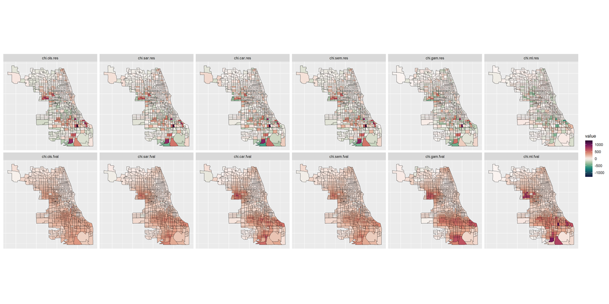

```r
chi.poly_f <- setDT(chi.poly_f)
chi.poly_f <- chi.poly_f[, chi.gam.res := chi_gam$residuals]
chi.poly_f <- chi.poly_f[, chi.gam.fval := chi_gam$fitted.values]
chi.poly_f <- chi.poly_f[, chi.ml.fval := ml_pred]
chi.poly_f <- chi.poly_f[, chi.ml.res := ml_res]

chi.poly_f_long <- setDT(melt(chi.poly_f, measure.vars =
                      c("chi.ols.res", "chi.sar.res", "chi.car.res", "chi.sem.res", "chi.gam.res","chi.ml.res",
                        "chi.ols.fval", "chi.sar.fval","chi.car.fval", "chi.sem.fval", "chi.gam.fval","chi.ml.fval" )))

chi.poly_f_long <- chi.poly_f_long[, scaled_res := scale(value), by = .(variable)]

qcut = function(x, n) {
  quantiles = seq(0, 1, length.out = n+1)
  cutpoints = unname(quantile(x, quantiles, na.rm = TRUE))
  cut(x, cutpoints, include.lowest = TRUE)
}

chi.poly_f_long <- chi.poly_f_long[, res_quant := qcut(value, 10)]


map_p <- ggplot(data = chi.poly_f_long, # the input data
           aes(x = long, y = lat, fill = value, group = group)) + # define variables
              geom_polygon() + # plot the boroughs
              geom_path(colour="black", lwd=0.05) + # borough borders
              coord_equal() + # fixed x and y scales
              facet_wrap(~ variable, ncol = 6) + # one plot per time slice
              scale_fill_paletteer_c("pals", "ocean.curl", direction = 1, limits = c(-1, 1) * max(abs(chi.poly_f_long$value))) +
              #scale_fill_distiller(palette = "RdBu") + # legend options
              theme(axis.text = element_blank(), # change the theme options
                    axis.title = element_blank(), # remove axis titles
                    axis.ticks = element_blank()) # remove axis ticks


map_p
```

## 3.10 Are the models good?

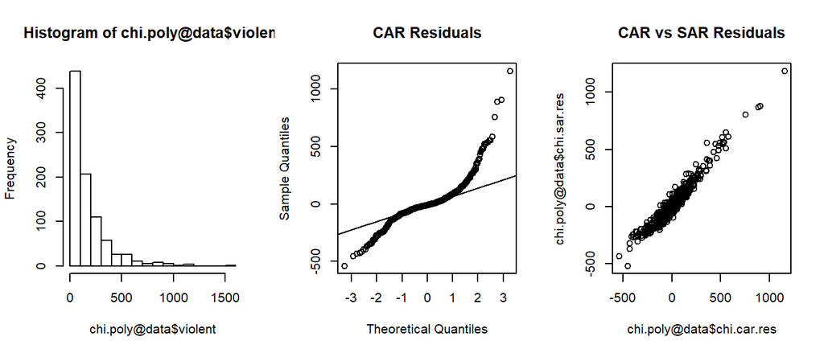

Yep they’re bad…

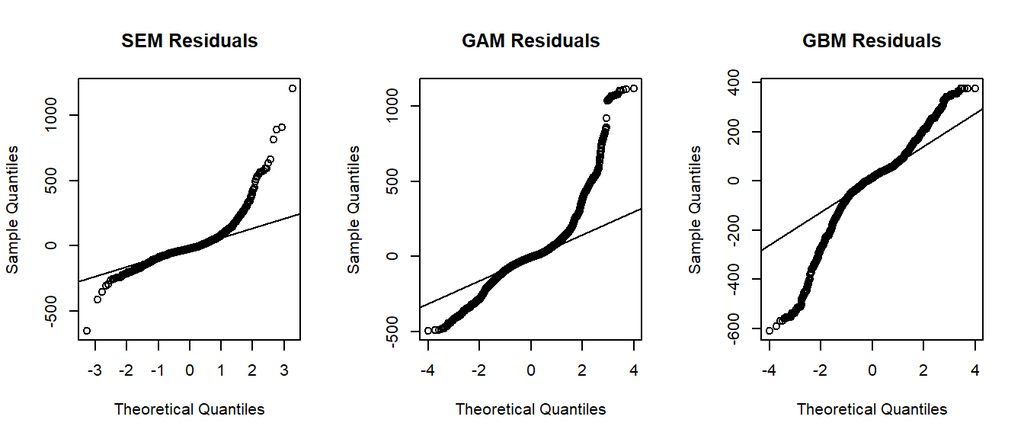

Not “good” but look at the residuals scale, a bit better from left to right.

## 3.11 Gaussian Random Markov Fields

If we really need a discrete version of the Gaussian Processes, then we should fit a GMRF. I’ll use another minimal example here because GMRF are much more computational extensive (laptop restriction).

```r
data_path = "C:/Users/xtbury/Documents/Projects/Italy projects/002_Zoning/Data files/"
file_name = "us_county_hs_only/us_county_hs_only.shp"
shp <- rgdal::readOGR(paste0(data_path, file_name))
## select michigan, and convert % to proportion
mich_df <- shp[shp$STATEFP %in% c(26), ] %>%   # add other FIPS codes as desired
  as.data.frame() %>%
  droplevels() %>%
  mutate(hsd = hs_pct / 100,
         county = stringr::str_replace(tolower(NAME), pattern='\\.', ''),
         county = factor(county))
nb <- spdep::poly2nb(shp[shp$STATEFP %in% c(26), ], row.names = mich_df$county)
names(nb) <- attr(nb, "region.id")
ctrl <- gam.control(nthreads = 6) # use 6 parallel threads, reduce if fewer physical CPU cores

gam_mrf <- gam(hsd ~ s(county, bs = 'mrf', xt = list(nb = nb)), # define MRF smooth
               data = mich_df,
               method = 'REML',
               family = betar,  # fit a beta regression
               control = ctrl)
summary(gam_mrf)
```

```
##
## Family: Beta regression(103.966)
## Link function: logit
##
## Formula:
## hsd ~ s(county, bs = "mrf", xt = list(nb = nb))
##
## Parametric coefficients:
##             Estimate Std. Error z value Pr(>|z|)
## (Intercept) -0.57837    0.02237  -25.85   <2e-16 ***
## ---
## Signif. codes:  0 '***' 0.001 '**' 0.01 '*' 0.05 '.' 0.1 ' ' 1
##
## Approximate significance of smooth terms:
##             edf Ref.df Chi.sq p-value
## s(county) 29.75  45.58  65.33  0.0297 *
## ---
## Signif. codes:  0 '***' 0.001 '**' 0.01 '*' 0.05 '.' 0.1 ' ' 1
##
## R-sq.(adj) =  0.492   Deviance explained = 67.4%
## -REML = -113.47  Scale est. = 1         n = 83
```

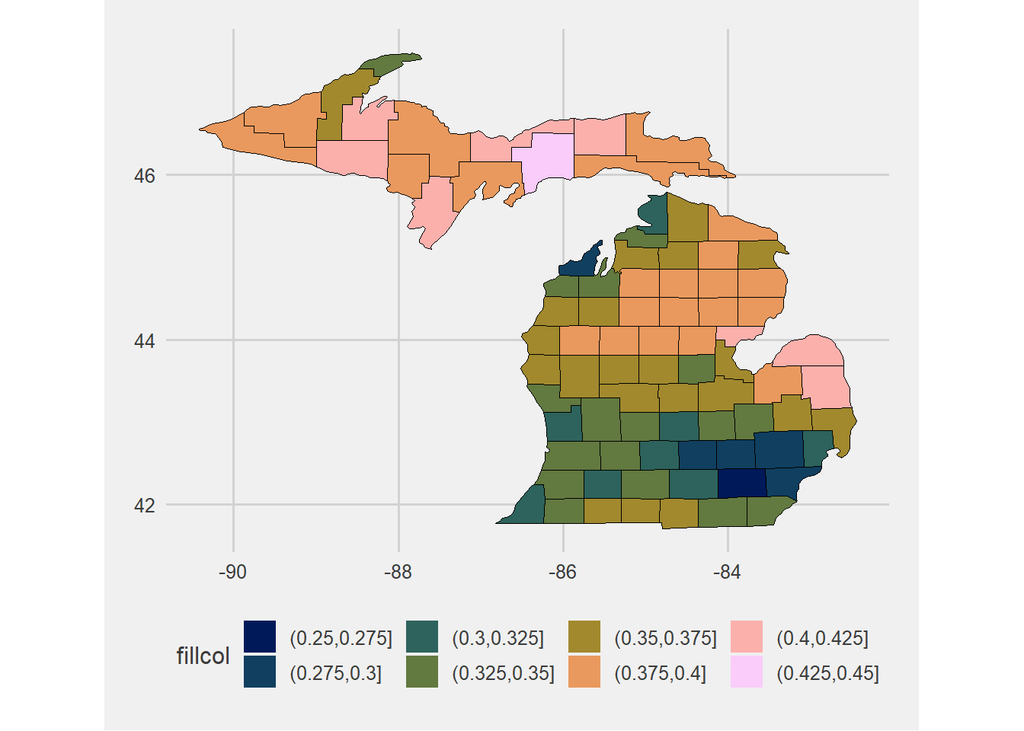

```r
mich_df = mich_df %>%
  mutate(fit = predict(gam_mrf, type='response'))

plotdat = map_data("county", 'michigan') %>%
  left_join(mich_df, by = c('subregion' = 'county')) %>%
  mutate(fillcol = cut(fit, breaks=seq(.25, .45, by = .025)))
# p = plotdat %>%
#   group_by(subregion) %>%
#   plot_ly(x = ~long, y = ~lat,
#           color = ~fillcol,
#           colors = viridis::plasma(50, begin=1, end=0),
#           text = ~subregion, hoverinfo = 'text') %>%
#   add_polygons(line = list(width = 0.4)) %>%
#   layout(title = "% with Maximum of HS Education in Michigan")

sub_reg_data <- plotdat %>% group_by(subregion)

map_p2 <- ggplot(data = sub_reg_data, # the input data
                aes(x = long, y = lat, fill = fillcol, group = group)) + # define variables
  geom_polygon() + # plot the boroughs
  geom_path(colour="black", lwd=0.05) + # borough borders
  coord_equal() + # fixed x and y scales
  scale_fill_scico_d(palette = "batlow")+ # batlow is the scientific version of the rainbow colour map
  theme_fivethirtyeight()
  #scale_fill_brewer(palette = "RdBu") + # legend options
  # theme(axis.text = element_blank(), # change the theme options
  #       axis.title = element_blank(), # remove axis titles
  #       axis.ticks = element_blank()) # remove axis ticks


map_p2
```

A beautiful example here: https://www.fromthebottomoftheheap.net/2017/10/19/first-steps-with-mrf-smooths/ The GMRF has the advantage to be smooth, the GBM pred may seems better but can be rather rough.